# Milk Caps in The Forest Assignment

Wang YueDuo, sdu202000700268

2022-03-11

## Question 1: Write down the Null and alternative hypotheses.

### My Answer:

The null hypotheses is: The mushrooms are randomly distributed through the forest. The alternative hypotheses is: The mushrooms are not randomly distributed through the forest, there are hot-spots where they are more numerous than in other locations.

## Question 2: Describe in 3 - 5 sentences what Null model (distribution) you are going to use and what statistical test and why.

### My Answer:

To solve this problem, I will consider poisson distribution as null model.

Because poisson distribution is used to calculate the probability of events occurring in a specific interval, which can be time, area and volume, so if the mushrooms are randomly distributed through the forest, it should follow the poisson distribution.(←this sentence referenced from lecture 04)

For the statistical test, Chi square test would be used.

Because chi square test can evaluate the quality of distribution fitting. (←this sentence referenced from lecture 04)

By chi square test,we get X-squared, df and p-value, which means if p-value < 0.05, null hypotheses can be rejected.

## Question 3: Generate the expected values (counts) based on a fitted Null model.

### My Answer:

First, we read the data file:

```r
milkcap.df <- read.csv("milkcap.csv",stringsAsFactors=T)

summary(milkcap.df)
```

```
##    specimens     count
##  Min.   :0   Min.   : 13.0
##  1st Qu.:1   1st Qu.: 15.0
##  Median :2   Median : 18.0
##  Mean   :2   Mean   : 57.6
##  3rd Qu.:3   3rd Qu.: 39.0
##  Max.   :4   Max.   :203.0
```

```r
#Here is data:
```

Then, we calculate the mean count of mushrooms μ:

```r
μ <- weighted.mean(milkcap.df$specimens,milkcap.df$count)
print(μ)
```

```
## [1] 0.6041667
```

```r
#we get μ,the mean count of mushrooms.
#Because in poisson distribution, λ = μ
λ <- μ
#Thus, we get the value of λ
```

Now calculate the poisson distribution, by using the λ we get:

```r
n <- 0:4
p <- dpois(n, λ)
c <- p * sum(milkcap.df$count)
print(c)
```

```
## [1] 157.4005474  95.0961640  28.7269662   5.7852918   0.8738201
```

```r
# This is the poisson distribution, and also the expected frequencies we get.
```

## Question 4: Make a plot or plots presenting the observed and the expected frequencies; you can use as many plots as you want, as long as they are appropriate for presentation of these data.

### My Answer:

First of all, plot the observed by barplot:

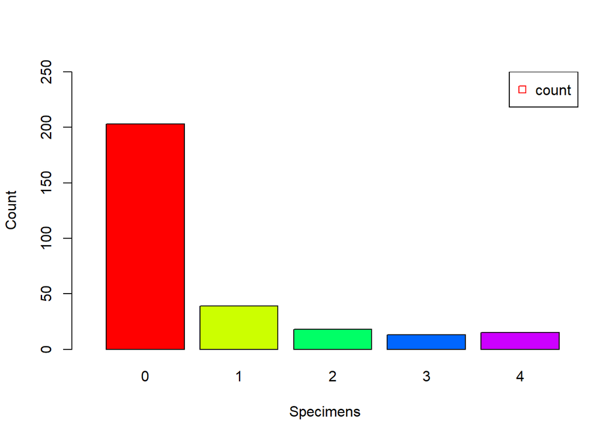

```r
barplot(milkcap.df$count,
    names.arg = milkcap.df$specimens,
    xlab="Specimens",
    ylab="Count",
    xlim=c(0,6),
    lwd=1,
    ylim=c(0,250),
    col=rainbow(5))

#Add the legend
legend("topright",
    legend=c("count"),
    col=rainbow(5),
    pch=0)
```

Then, plot the observed and expected frequencies, and also make a comparation between them:

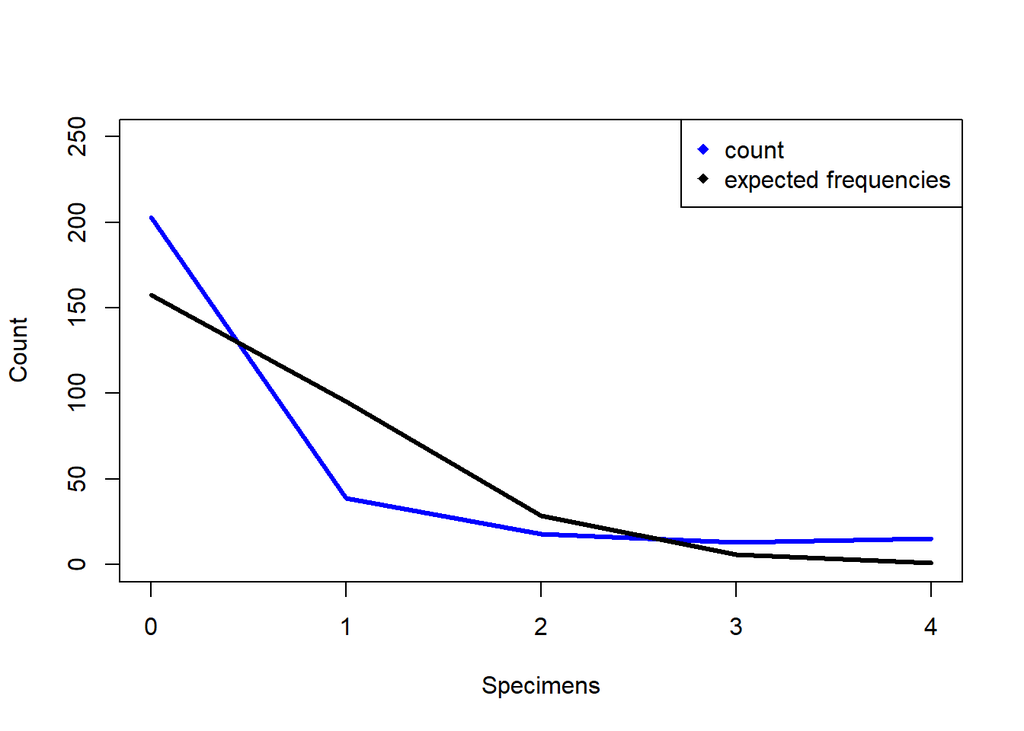

```r
plot(milkcap.df$specimens,milkcap.df$count,
    xlab="Specimens",
    ylab="Count",
    lwd=3,
    type="l",
    xlim=c(0,4),
    ylim=c(0,250),
    col="blue")

lines(milkcap.df$specimens,c,
      xlab="Specimens",
      ylab="Count",
      col="black",
      lwd=3)

#Add the legend
legend("topright",
    legend=c("count","expected frequencies"),
    col=c("blue","black"),
    pch=c(18,18))
```

```r
#The plots are presented here:
```

## Question 5: Perform the statistical test observing its assumptions.

### My Answer:

First of all, put the expected frequency in to the data frame:

```r
milkcap.df$expected <- round(c, 2)
milkcap.df
```

```
##   specimens count expected
## 1         0   203   157.40
## 2         1    39    95.10
## 3         2    18    28.73
## 4         3    13     5.79
## 5         4    15     0.87
```

“One of the assumptions of the χ2 test is that no more than 20% of the categories have expected frequencies less than 5 and neither category have expected frequency than 1.” (This sentence is cited from Workshop04) Thus, It should be checked that if there is any data obey to this rule.

```r
#Show the data that is not following expected frequencies less than 5:
milkcap.df[milkcap.df$expected < 5, ]
```

```
##   specimens count expected
## 5         4    15     0.87
```

Obviously, the expected of specimens 4 is not following expected frequencies less than 5. To solve this problem, the expected frequencies and count of specimens 4 should be combined into the expected and count of specimens 3:

```r
agregated <- milkcap.df[(milkcap.df$specimens <= 3),]
#Combine the expected frequencies
agregated[(milkcap.df$specimens == 3),]$expected = sum(milkcap.df[milkcap.df$specimens >= 3, ]$expected)
#Also for the count:
agregated[(milkcap.df$specimens == 3),]$count = sum(milkcap.df[milkcap.df$specimens >= 3, ]$count)
print(agregated)
```

```
##   specimens count expected
## 1         0   203   157.40
## 2         1    39    95.10
## 3         2    18    28.73
## 4         3    28     6.66
```

Now, we can use chi square test, by using chisq() function:

```r
chisq <- chisq.test(agregated$count,c = agregated$expected, rescale.p = T)
print(chisq)
```

[output not shown]

## Question 6: Write 5 - 10 sentences discussing the results, conclusions and your answer to the research question.

### My answer:

The research question is：Are the milk caps randomly distributed around the forest?

The null hypotheses is: The mushrooms are randomly distributed through the forest, while the alternative hypotheses is: The mushrooms are not randomly distributed through the forest, there are hot-spots where they are more numerous than in other locations.

Considering the probability of events occurring in a specific interval(area are used in this problem), We used possion distribution, and used chi square test to evaluate the quality of distribution fitting.

barplot and line plot are both used to presenting the observed and the expected frequencies, and some codes are referenced from workshop04.

It seems that the observed and expected frequencies are not fitted well.

### Thus, the final conclusion is:

The mushrooms are not following poisson distribution, means that they are not randomly distributed through the forest, it’s true that there are some hot-spot where they are more numerous than in other locations!

### Open comments:

To improve this experiment, more specimens should be taken, in order to get a more accurate distribution fitting and conclusion.

## End of Assignment: Milk Caps in The Forest